# Exploring Potential Influencers of Math Student Performance

DATA 2401 Group Project

Lauren Duvall, Shikyna William, Thomas Linden

2025-04-29

## Introduction

Why do some high-schoolers excel in math, while others drop out? Portuguese educators often ask themselves this question, but struggle to find key factors that influence student success—making it difficult to improve results.

This reproducible workflow reveals not only blaring impactors (prior grades), but also subtler effects (weekday vs weekend drinking). As the dataset contains many factors, we utilize two tools initially to narrow down the focus of the report’s investigation; a correlation heatmap, and a tables comparing each factor’s average final grades.

## Objective

Our goal is to determine factors that have the most significant impact on student performance in the math program. In addition, we hope to discover factors which may seem influential based on intuition but prove otherwise after analyzing the data.

### Categories Analyzed

- Academic Support & Study Habits
  - Which factors are the most predictive of final grades?
  - Does internet access at home improve the efficacy of studying?
- School & Demographics
  - Do students from different schools show significant differences in final grade?
  - Is there an interaction between romantic relationships and gender on the final grade?
- Family Background
  - Do parents’ education levels, affect a student’s performance?
  - How do family relationships and presence of educational support at home affect student performance?
- Activities & Social Life
  - Do romantic relationships affect student performance?
  - Is there a link between extracurricular activities and absences?
- Health & Lifestyle
  - What is the relationship between alcohol consumption (weekday vs weekend) and final grades?
- Academic Performance
  - Do students with past failures continue to perform poorly?
  - Does weekly study time affect performance consistently across all terms?

## Load Packages

```r
library(dplyr)      # basic data manipulation
library(tibble)     # nicer data tables
library(tidyr)      # table pivots and reshaping data
library(plotly)     # add interactivity to ggplot graphs
library(DT)         # interactive HTML data tables
library(GGally)     # ggparcoord()'s parallel coordinate plots
library(ggridges)   # ridge plots
library(kableExtra) # formatting tables in HTML
library(patchwork)  # combining multiple plots together
library(ggforce)    # extended ggplot annotations
library(ggplot2)    # main plotting package
library(htmltools)  # manually manipulate positioning of HTML divs
```

## Data Cleaning

```r
raw <- read.csv("Math-Students.csv")
# Rename cols, convert to factors, add any necessary levels, transmute to drop old columns
formatted <- raw %>% transmute(
  school = as.factor(school),
  sex = as.factor(sex),
  age = age,
  address = as.factor(address),
  fam_size = as.factor(famsize),
  parental_stat = as.factor(Pstatus),
  mom_edu = factor(Medu, levels = 0:4, ordered = TRUE),
  dad_edu = factor(Fedu, levels = 0:4, ordered = TRUE),
  mom_job = as.factor(Mjob),
  dad_job = as.factor(Fjob),
  attend_reason = as.factor(reason),
  guardian = as.factor(guardian),
  travel_time = traveltime,
  study_time = studytime,
  failures = failures,
  school_support = as.factor(schoolsup),
  family_support = as.factor(famsup),
  extra_paid_classes = as.factor(paid),
  activities = as.factor(activities),
  nursery_school = as.factor(nursery),
  pursue_higher_edu = as.factor(higher),
  internet_use = as.factor(internet),
  romantic = as.factor(romantic),
  family_relationship = factor(famrel, levels = 1:5, ordered = TRUE),
  free_time = factor(freetime, levels = 1:5, ordered = TRUE),
  go_out_w_friends = factor(goout, levels = 1:5, ordered = TRUE),
  workday_alcohol = factor(Dalc, levels = 1:5, ordered = TRUE),
  weekend_alcohol = factor(Walc, levels = 1:5, ordered = TRUE),
  health = factor(health, levels = 1:5, ordered = TRUE),
  absences = absences,
  period1_grade = G1,
  period2_grade = G2,
  final_grade = G3
)
sum(is.na(formatted))
```

Using transmute(), we changed character columns to factors, and those with levels have been ordered. We used transmute instead of mutate so original columns would drop and there would be no redundant data. There are no missing values in the dataset which was confirmed with sum(is.na()).

```r
# Make scrollable data table
datatable(formatted,
  rownames = FALSE,
  options = list(
    pageLength = 10,
    scrollX = TRUE,
    autoWidth = TRUE,
    columnDefs = list(list(className = "dt-center", targets = "_all"))
  )
)
```

| school | sex | age | address | fam_size | parental_stat | mom_edu | dad_edu | mom_job | dad_job | attend_reason | guardian | travel_time | study_time | failures | school_support | family_support | extra_paid_classes | activities | nursery_school | pursue_higher_edu | internet_use | romantic | family_relationship | free_time | go_out_w_friends | workday_alcohol | weekend_alcohol | health | absences | … |
| --- | --- | --- | --- | --- | --- | --- | --- | --- | --- | --- | --- | --- | --- | --- | --- | --- | --- | --- | --- | --- | --- | --- | --- | --- | --- | --- | --- | --- | --- | --- |
| GP | F | 18 | U | GT3 | A | 4 | 4 | at_home | teacher | course | mother | 2 | 2 | 0 | yes | no | no | no | yes | yes | no | no | 4 | 3 | 4 | 1 | 1 | 3 | 6 | … |
| GP | F | 17 | U | GT3 | T | 1 | 1 | at_home | other | course | father | 1 | 2 | 0 | no | yes | no | no | no | yes | yes | no | 5 | 3 | 3 | 1 | 1 | 3 | 4 | … |
| GP | F | 15 | U | LE3 | T | 1 | 1 | at_home | other | other | mother | 1 | 2 | 3 | yes | no | yes | no | yes | yes | yes | no | 4 | 3 | 2 | 2 | 3 | 3 | 10 | … |
| GP | F | 15 | U | GT3 | T | 4 | 2 | health | services | home | mother | 1 | 3 | 0 | no | yes | yes | yes | yes | yes | yes | yes | 3 | 2 | 2 | 1 | 1 | 5 | 2 | … |
| GP | F | 16 | U | GT3 | T | 3 | 3 | other | other | home | father | 1 | 2 | 0 | no | yes | yes | no | yes | yes | no | no | 4 | 3 | 2 | 1 | 2 | 5 | 4 | … |
| GP | M | 16 | U | LE3 | T | 4 | 3 | services | other | reputation | mother | 1 | 2 | 0 | no | yes | yes | yes | yes | yes | yes | no | 5 | 4 | 2 | 1 | 2 | 5 | 10 | … |
| GP | M | 16 | U | LE3 | T | 2 | 2 | other | other | home | mother | 1 | 2 | 0 | no | no | no | no | yes | yes | yes | no | 4 | 4 | 4 | 1 | 1 | 3 | 0 | … |
| GP | F | 17 | U | GT3 | A | 4 | 4 | other | teacher | home | mother | 2 | 2 | 0 | yes | yes | no | no | yes | yes | no | no | 4 | 1 | 4 | 1 | 1 | 1 | 6 | … |
| GP | M | 15 | U | LE3 | A | 3 | 2 | services | other | home | mother | 1 | 2 | 0 | no | yes | yes | no | yes | yes | yes | no | 4 | 2 | 2 | 1 | 1 | 1 | 0 | … |
| GP | M | 15 | U | GT3 | T | 3 | 4 | other | other | home | mother | 1 | 2 | 0 | no | yes | yes | yes | yes | yes | yes | no | 5 | 5 | 1 | 1 | 1 | 5 | 0 | … |

[output cut: 389 more lines]

The “DT” package is an R interface to the Javascript library “DataTables”. With help from the documentation, we enabled horizontal scrolling, auto column widths, and centered values within each column via a list of lists.

- **columnDefs:** passed to JS as an array of objects (list of lists). Why? Each inner list can apply a different css class or apply to a different set of columns. Options, options, options!
- **dt-center:** applies the center data css class
- **targets:** applies settings to all columns

## Key Terms

- **School**: Either Gabriel Pereira or Mousinho da Silveira
- **Address**: Urban or Rural
- **Attendance Reason**: Close to ‘home’, school ‘reputation’, ‘course’ preference or ‘other’
- **Extra Paid Classes**: Extra paid classes within the course subject (Math or Portuguese). Yes or No.
- **Nursery School**: Portugal’s version of Pre-School. Attended? Yes or No.
- **Family Support**: Family educational suppor. Yes or No.
- **Family Relationship**: Quality of family relationships. Scale from 1-5, very bad to excellent.
- **Workday Alcohol**: How much drinking during the week. Scale from 1-5, low to high level of drinking.
- **Weekend Alcohol**: How much drinking during the weekend. Scale from 1-5, low to high level of drinking.
- **Health**: Current health status. Scale from 1-5, very bad to very good.

## Exploratory Data Analysis

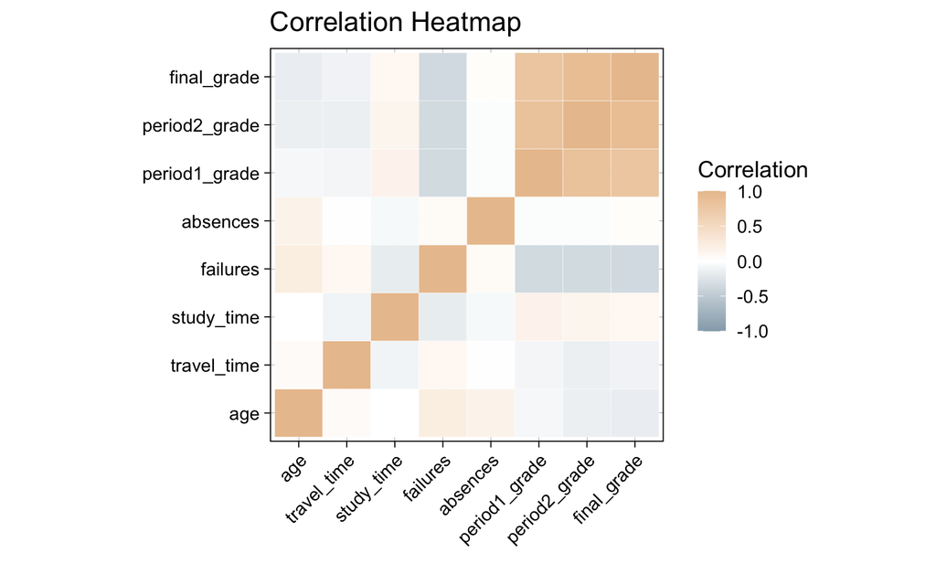

```r
# Correlation table
cor_df <- formatted %>%
  select(where(is.numeric)) %>%
  cor(use = "complete.obs") %>%
  as.table() %>%
  as.data.frame()

colnames(cor_df) <- c("Var1", "Var2", "Correlation")

cor_df %>% ggplot(aes(Var1, Var2, fill = Correlation)) +
  geom_tile(color = "white") +
  scale_fill_gradient2(
    low = "#95aab7", mid = "white", high = "#eac39c",
    midpoint = 0, limit = c(-1, 1), name = "Correlation"
  ) +
  labs(title = "Correlation Heatmap", x = "", y = "") +
  theme_linedraw(base_size = 14) +
  coord_fixed() +
  theme(axis.text.x = element_text(angle = 45, vjust = 1, hjust = 1))
```

**Intuitive relationships:**

- Grades from all three periods are strongly positively correlated.
- Grades are negatively correlated with the number of failures.

**Some relationships to look into more:**

- Travel time is inversely proportional to study time.
- Number of failures is positively correlated to travel time; negatively correlated with study time.

**Features not in the correlation heatmap: (Potential 3rd Degrees of Comparison)**

- All factor features, including but not limited to: parental, financial, and social details.

## Academic Support & Study Habits

### Which factors are most predictive of final grades?

```r
# Avg to compare to
overall_avg_final <- mean(formatted$final_grade)

# Get factor columns
factor_cols <- names(formatted)[sapply(formatted, is.factor)]

# Create summary table
factor_effects <- lapply(factor_cols, function(var) { # Loop through each factor
  formatted %>%
    group_by(.data[[var]]) %>% # Group by factor
    summarise( # Get average final grade for the factor
      avg_grade = mean(final_grade, na.rm = TRUE),
      .groups = "drop"
    ) %>%
    mutate( # Make new column w/ group level as character
      variable = var,
      level = as.character(.data[[var]]),
      diff_from_overall = avg_grade - overall_avg_final # Diff from overall avg
    ) %>%
    select(variable, level, avg_grade, diff_from_overall)
}) %>% bind_rows() # After looping, combine all columns into a df
```

```r
minimal_table <- factor_effects %>%
  filter(abs(diff_from_overall) < 1) %>%
  select(Factor = variable, Level = level, `Factor Avg` = avg_grade, Difference = diff_from_overall) %>%
  kable(digits = 2, caption = "Minimal Impact: ∆ &lt; 1") %>%
  kable_styling(full_width = FALSE) %>%
  scroll_box(width = "100%", height = "500px")

significant_table <- factor_effects %>%
  filter(abs(diff_from_overall) >= 1.5) %>%
  select(Factor = variable, Level = level, `Factor Avg` = avg_grade, Difference = diff_from_overall) %>%
  kable(digits = 2, caption = "Significant Impact: ∆ ≥ 1.5") %>%
  kable_styling(full_width = FALSE) %>%
  scroll_box(width = "100%", height = "500px")

# Show tables side by side
browsable(
  tagList(
    div(
      style = "display: flex; gap: 2%;",
      div(style = "flex: 1;", HTML(minimal_table)),
      div(style = "flex: 1;", HTML(significant_table))
    )
  )
)
```

Minimal Impact: ∆ < 1

| Factor | Level | Factor Avg | Difference |
| --- | --- | --- | --- |
| school | GP | 10.49 | 0.11 |
| school | MS | 9.62 | -0.76 |
| sex | F | 9.97 | -0.41 |
| sex | M | 10.83 | 0.45 |
| address | R | 9.51 | -0.87 |
| address | U | 10.63 | 0.25 |
| fam_size | GT3 | 10.13 | -0.25 |
| fam_size | LE3 | 11.00 | 0.62 |
| parental_stat | A | 11.20 | 0.81 |
| parental_stat | T | 10.29 | -0.09 |
| mom_edu | 2 | 9.73 | -0.65 |
| mom_edu | 3 | 10.30 | -0.08 |
| dad_edu | 2 | 10.26 | -0.12 |
| dad_edu | 3 | 10.66 | 0.28 |
| dad_edu | 4 | 11.19 | 0.81 |
| mom_job | other | 9.82 | -0.56 |
| mom_job | services | 11.02 | 0.64 |
| mom_job | teacher | 10.79 | 0.41 |
| dad_job | at_home | 10.00 | -0.38 |
| dad_job | other | 10.18 | -0.20 |
| dad_job | services | 10.24 | -0.14 |
| attend_reason | course | 9.78 | -0.60 |
| attend_reason | home | 10.26 | -0.12 |
| attend_reason | other | 11.17 | 0.79 |
| attend_reason | reputation | 11.07 | 0.68 |
| guardian | father | 10.69 | 0.31 |
| guardian | mother | 10.43 | 0.05 |
| school_support | no | 10.52 | 0.14 |
| school_support | yes | 9.43 | -0.95 |
| family_support | no | 10.55 | 0.17 |
| family_support | yes | 10.27 | -0.11 |
| extra_paid_classes | no | 9.93 | -0.45 |
| extra_paid_classes | yes | 10.92 | 0.54 |
| activities | no | 10.27 | -0.11 |
| activities | yes | 10.49 | 0.11 |
| nursery_school | no | 9.81 | -0.57 |
| nursery_school | yes | 10.54 | 0.15 |
| pursue_higher_edu | yes | 10.57 | 0.19 |
| internet_use | yes | 10.62 | 0.24 |
| romantic | no | 10.78 | 0.40 |
| romantic | yes | 9.58 | -0.81 |
| family_relationship | 1 | 10.62 | 0.24 |
| family_relationship | 2 | 9.89 | -0.49 |
| family_relationship | 3 | 10.04 | -0.34 |
| family_relationship | 4 | 10.36 | -0.02 |
| family_relationship | 5 | 10.69 | 0.31 |
| free_time | 1 | 9.84 | -0.54 |
| free_time | 3 | 9.71 | -0.67 |
| free_time | 4 | 10.43 | 0.05 |
| free_time | 5 | 11.30 | 0.92 |
| go_out_w_friends | 1 | 9.87 | -0.51 |
| go_out_w_friends | 2 | 11.04 | 0.66 |
| go_out_w_friends | 3 | 10.96 | 0.58 |
| go_out_w_friends | 4 | 9.65 | -0.73 |
| workday_alcohol | 1 | 10.68 | 0.30 |
| workday_alcohol | 3 | 10.50 | 0.12 |
| workday_alcohol | 4 | 9.89 | -0.49 |
| workday_alcohol | 5 | 10.67 | 0.29 |
| weekend_alcohol | 1 | 10.74 | 0.35 |
| weekend_alcohol | 2 | 9.94 | -0.44 |
| weekend_alcohol | 3 | 10.72 | 0.34 |
| weekend_alcohol | 4 | 9.69 | -0.69 |
| weekend_alcohol | 5 | 10.14 | -0.24 |
| health | 2 | 10.22 | -0.16 |
| health | 3 | 10.01 | -0.37 |
| health | 4 | 9.93 | -0.45 |
| health | 5 | 10.40 | 0.02 |

Significant Impact: ∆ ≥ 1.5

| Factor | Level | Factor Avg | Difference |
| --- | --- | --- | --- |
| mom_edu | 0 | 13.00 | 2.62 |
| mom_edu | 1 | 8.68 | -1.70 |
| dad_edu | 0 | 13.00 | 2.62 |
| mom_job | health | 12.15 | 1.77 |
| dad_job | teacher | 11.97 | 1.58 |
| pursue_higher_edu | no | 6.80 | -3.58 |

After calculating the average final grade, all factor columns ran through a custom function to compare the average final grade of students across different factor levels.

We then combined the results with bind_rows()- levels with averages **< 1** point of the overall mean were considered to have **minimal individual impact**, while those that differed by **≥ 1.5** points were classified to have **significant individual impact**.

### Does internet access at home improve the efficacy of studying?

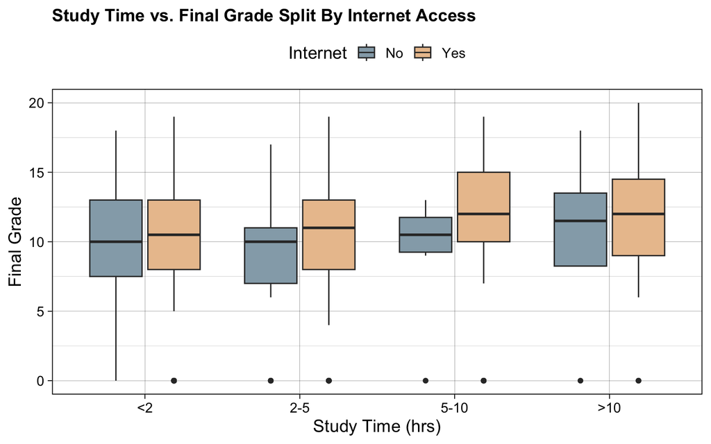

```r
# Box plot, study time and internet access
formatted %>%
  ggplot(aes(x = factor(study_time),
             y = final_grade,
             fill = factor(internet_use, levels = c("no", "yes"), labels = c("No", "Yes")))) +
  geom_boxplot() +
  scale_x_discrete(labels = c(
    "1" = "<2",
    "2" = "2-5",
    "3" = "5-10",
    "4" = ">10"
  )) +
  scale_fill_manual(values = c(
    "No" = "#95aab7",
    "Yes" = "#eac39c"
  )) +
  labs(x = "Study Time (hrs)",
       y = "Final Grade",
       fill = "Internet", title = "Study Time vs. Final Grade Split By Internet Access") +
  theme_linedraw(base_size = 14) +
  theme(
    plot.title = element_text(face = "bold", size = 14),
    legend.position = "top"
  )
```

Across all buckets of student study time, average final grades are marginally better for students with internet access at home.

## School & Demographics

### Do students from different schools show significant differences in final grade?

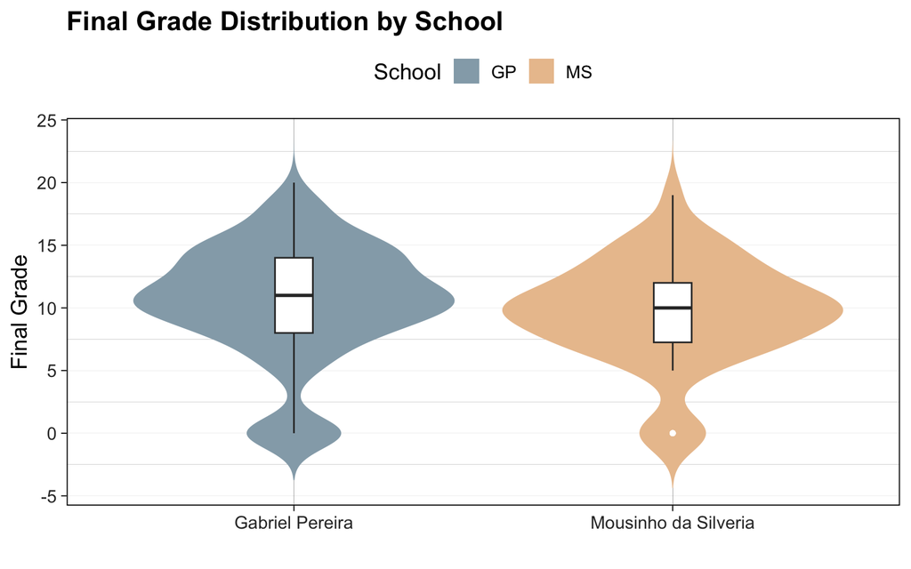

```r
plot_data <- formatted %>%
  select(school, final_grade) %>%
  group_by(school) %>%
  summarise(
    mean_period3 = mean(final_grade, na.rm = TRUE),
    median_period3 = median(final_grade, na.rm = TRUE),
    sd_period3 = sd(final_grade, na.rm = TRUE),
    count = n()
  )

# Violin plot, schools
formatted %>%
  ggplot(aes(x = school, y = final_grade, fill = school)) +
  geom_violin(trim = FALSE, color = NA) +
  geom_boxplot(width = 0.1, fill = "white", outlier.color = "white", outlier.shape = 16) +
  scale_fill_manual(values = c("GP" = "#95aab7", "MS" = "#eac39c")) +
  labs(
    title = "Final Grade Distribution by School",
    x = "",
    y = "Final Grade",
    fill = "School"
  ) +
  theme_linedraw(base_size = 14) +
  theme(
    plot.title = element_text(face = "bold"),
    plot.subtitle = element_text(size = 11),
    axis.text = element_text(color = "gray20"),
    panel.grid.major.y = element_line(color = "gray85"),
    legend.position = "top"
  ) +
  scale_x_discrete(labels = c(
    "GP" = "Gabriel Pereira",
    "MS" = "Mousinho da Silveria"
  ))
```

The IQR for Mousinho da Silveria is smaller with failures being outliers, but both schools’ average is relatively in line with on another.

**The selection of school has no evidence of affecting student performance.**

### Is there an interaction between romantic relationships and gender on the final grade?

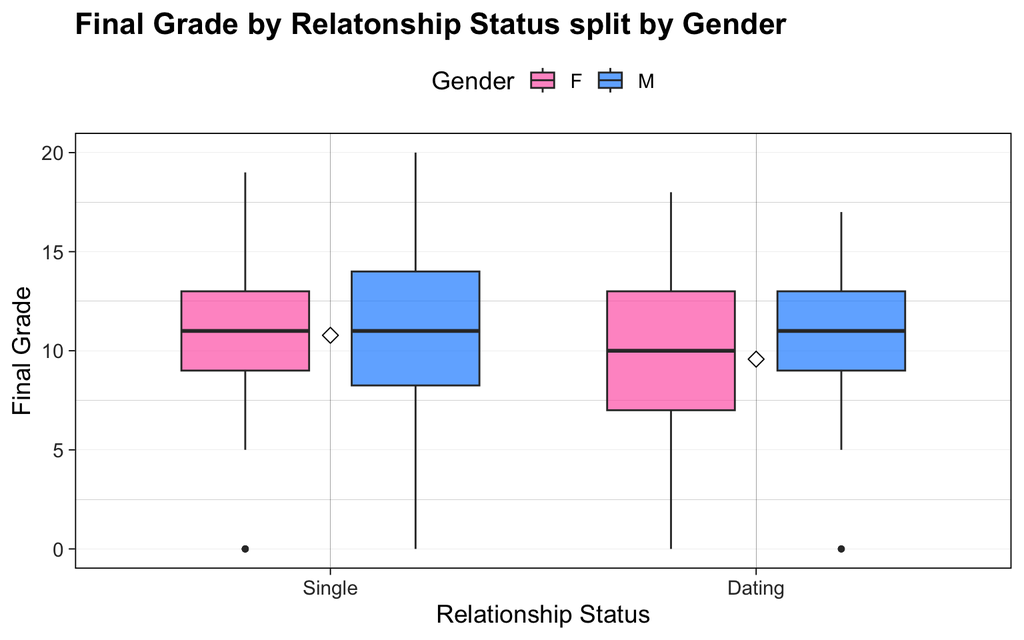

```r
# Box plot, romance and gender
formatted %>%
  ggplot(aes(x = romantic, y = final_grade, fill = sex)) +
  geom_boxplot(position = position_dodge(0.8), width = 0.6, outlier.shape = 16, alpha = 0.7) +
  scale_fill_manual(values = c("F" = "#FF69B4", "M" = "#1E90FF")) +
  labs(
    title = "Final Grade by Relatonship Status split by Gender",
    x = "Relationship Status",
    y = "Final Grade",
    fill = "Gender"
  ) +
  stat_summary(fun = mean, geom = "point", shape = 23, size = 3, fill = "white", color = "black", position = position_dodge(0.8)) +
  theme_linedraw(base_size = 14) +
  theme(
    plot.title = element_text(face = "bold"),
    plot.subtitle = element_text(size = 11),
    axis.text = element_text(color = "gray20"),
    panel.grid.major.y = element_line(color = "gray85"),
    legend.position = "top"
  ) +
  scale_x_discrete(labels = c(
    "no" = "Single",
    "yes" = "Dating"
  ))
```

There is correlation between relationship status and final grades when comparing by gender.

Females who are dating have a lower median, minimum, and IQR.

**Men who are dating are affected in the opposite manner when dating**, showing a higher minimum and Q1 with failures consisting of only outliers.

## Family Background

### Do parents’ education levels, affect a student’s performance?

```r
# Combine education levels and average final grades for geom_segment
education_vs_means <- formatted %>%
  mutate(
    mom_edu_num = as.numeric(as.character(mom_edu)),
    dad_edu_num = as.numeric(as.character(dad_edu)),
    both_edu = mom_edu_num + dad_edu_num
  ) %>%
  group_by(both_edu) %>%
  summarise(mean_grade = mean(final_grade, na.rm = TRUE))
```

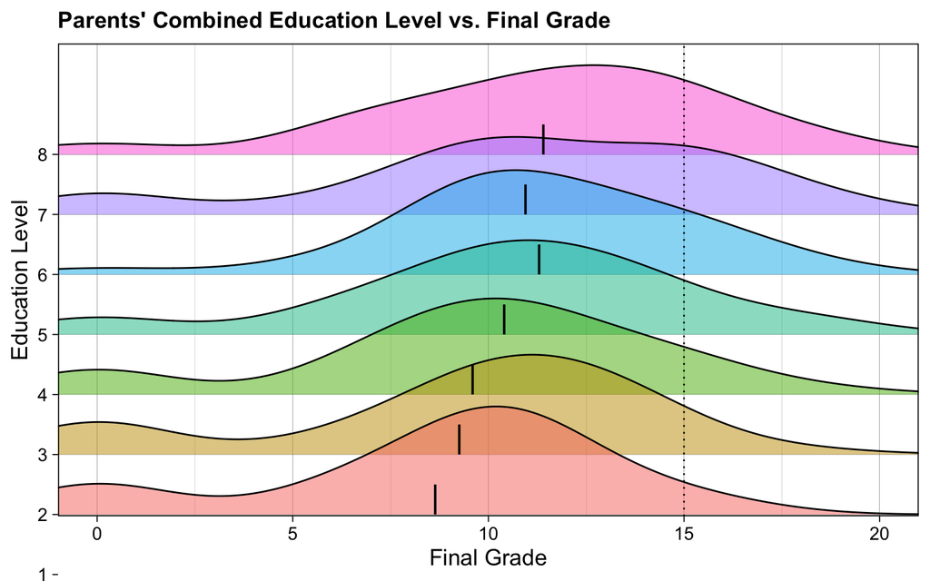

```r
# Ridge plot of each combined parental education level
formatted %>%
  mutate(
    mom_edu_num = as.numeric(as.character(mom_edu)),
    dad_edu_num = as.numeric(as.character(dad_edu)),
    both_edu = mom_edu_num + dad_edu_num
  ) %>%
  ggplot(aes(y = factor(both_edu), x = final_grade, fill = factor(both_edu))) +
  geom_density_ridges(alpha = 0.5, bandwidth = 2) +
  geom_vline(xintercept = 15, linetype = "dotted") +
  geom_segment(
    data = education_vs_means,
    aes(x = mean_grade, xend = mean_grade, y = both_edu, yend = both_edu + 0.5),
    linetype = "solid", linewidth = 0.7, inherit.aes = FALSE
  ) +
  theme_linedraw(base_size = 14) +
  theme(
    legend.position = "none",
    panel.spacing = unit(0.5, "lines"),
    plot.title = element_text(face = "bold", size = 14)
  ) +
  labs(
    x = "Final Grade", y = "Education Level",
    title = "Parents' Combined Education Level vs. Final Grade"
  ) +
  coord_cartesian(ylim = c(2.57, 9.25), xlim = c(0, 20))
```

### How do family relationships and presence of educational support at home affect student performance?

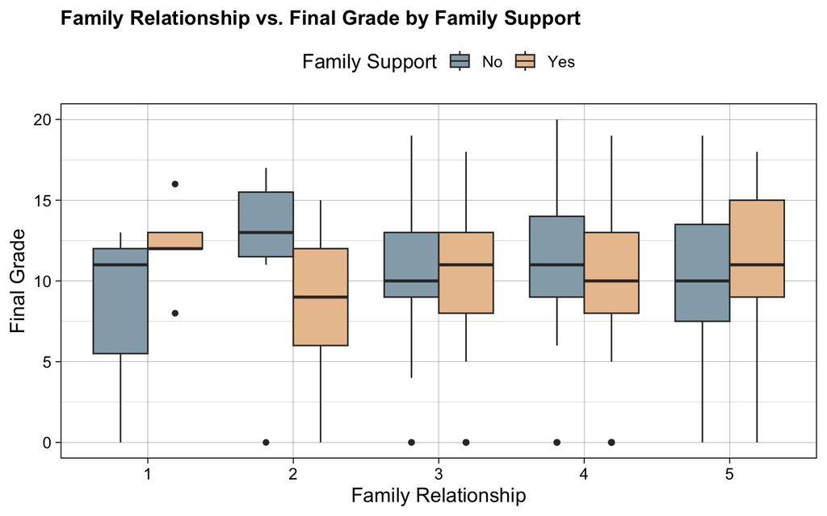

```r
# Box plot, family support, relationship
formatted %>%
  ggplot(aes(x = factor(family_relationship), y = final_grade, fill = factor(family_support, levels = c("no", "yes"), labels = c("No", "Yes")))) +
  geom_boxplot(position = position_dodge(width = 0.75)) +
  theme_linedraw(base_size = 14) +
  labs(x = "Family Relationship", fill = "Family Support", y = "Final Grade", title = "Family Relationship vs. Final Grade by Family Support") +
  theme(
    plot.title = element_text(face = "bold", size = 14),
    legend.position = "top"
  ) +
  scale_fill_manual(values = c(
    "No" = "#95aab7",
    "Yes" = "#eac39c"
  ))
```

**There is no clear relationship** between final grades and either family relationship quality or family educational support.

## Activities and Social Life

### Do romantic relationships affect student performance?

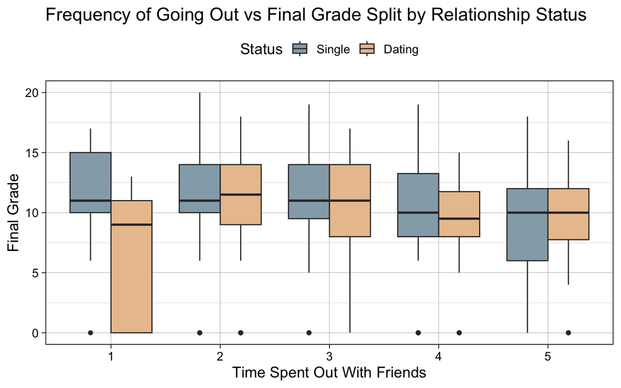

```r
# Box plot, romance, going out with friends
formatted %>%
  ggplot(aes(x = factor(go_out_w_friends), y = final_grade, fill = factor(romantic, levels = c("no", "yes"), labels = c("Single", "Dating")))) +
  geom_boxplot(position = position_dodge(width = .75)) +
  labs(x = "Time Spent Out With Friends", y = "Final Grade", fill = "Status", title = "Frequency of Going Out vs Final Grade Split by Relationship Status") +
  scale_fill_manual(
    values = c("Single" = "#95aab7", "Dating" = "#eac39c"),
  ) +
  theme_linedraw(base_size = 14) +
  theme(legend.position = "top")
```

Among those who rarely go out with friends, those in a romantic relationship have a notable drop in grades- which suggests **time spent dating detracts not only from time spent with friends, but also studying.**

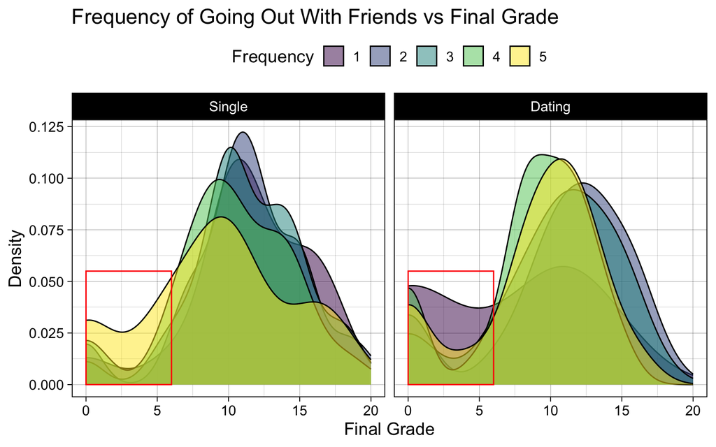

```r
# Density plots, romance, going out with friends
formatted %>%
  ggplot(aes(fill = factor(go_out_w_friends), x = final_grade)) +
  geom_density(alpha = .5) +
  annotate("rect", xmin = 0, xmax = 6, ymin = 0, ymax = .055, fill = NA, color = "red", alpha = .33) +
  labs(x = "Final Grade", y = "Density", fill = "Frequency", title = "Frequency of Going Out With Friends vs Final Grade") +
  facet_grid(~romantic, labeller = labeller(romantic = c("yes" = "Dating", "no" = "Single"))) +
  theme_linedraw(base_size = 14) +
  theme(legend.position = "top")
```

**Among single students, those who often go out with friends have the lowest scores.**

In constrast, **students in a romantic relationship have the lowest scores when rarely going out with friends**, echoing the conclusion drawn from the previous plot.

### Is there a link between extracurricular activities and absences?

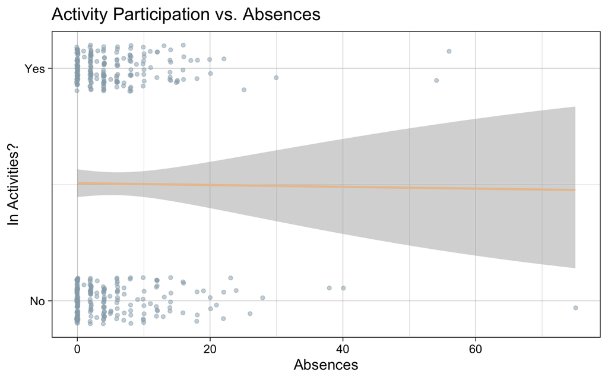

```r
# Smooth and jitter, absences and activities
formatted %>%
  mutate(activity_boolean = as.numeric(activities == "yes")) %>%
  ggplot(aes(x = absences, y = activity_boolean)) +
  geom_jitter(height = 0.1, width = 0.1, alpha = 0.5, color = "#95aab7") +
  geom_smooth(
    method = "glm",
    method.args = list(family = "binomial"),
    se = TRUE, color = "#eac39c",
    formula = y ~ x
  ) +
  scale_y_continuous(
    breaks = c(0, 1),
    labels = c("No", "Yes")
  ) +
  labs(
    x = "Absences",
    y = "In Activities?",
    title = "Activity Participation vs. Absences"
  ) +
  theme_linedraw(base_size = 14)
```

**A student’s participation in activities is not a strong indicator of their absence from classes.**

## Health & Lifestyle

### What is the relationship between alcohol consumption (weekdays vs weekends) and final grades?

```r
weekend_summ <- formatted %>%
  group_by(weekend_alcohol) %>%
  summarise(
    AvgFinalGrade = round(mean(final_grade), 2),
    n = n()
  )

workday_summ <- formatted %>%
  group_by(workday_alcohol) %>%
  summarise(
    AvgFinalGrade = round(mean(final_grade), 2),
    n = n()
  )

kable(weekend_summ, caption = "Weekend Alcohol Consumption vs Final Grade")
```

Weekend Alcohol Consumption vs Final Grade

| weekend_alcohol | AvgFinalGrade | n |
| --- | --- | --- |
| 1 | 10.74 | 151 |
| 2 | 9.94 | 89 |
| 3 | 10.72 | 80 |
| 4 | 9.69 | 51 |
| 5 | 10.14 | 28 |

```r
kable(workday_summ, caption = "Weekday Alcohol Consumption vs Final Grade")
```

Weekday Alcohol Consumption vs Final Grade

| workday_alcohol | AvgFinalGrade | n |
| --- | --- | --- |
| 1 | 10.68 | 280 |
| 2 | 9.25 | 75 |
| 3 | 10.50 | 26 |
| 4 | 9.89 | 9 |
| 5 | 10.67 | 9 |

Drinking on the weekend vs drinking on the weekday has **little to no effect on final math grade performance.**

## Academic Performance

### Do students with past failures continue to perform poorly?

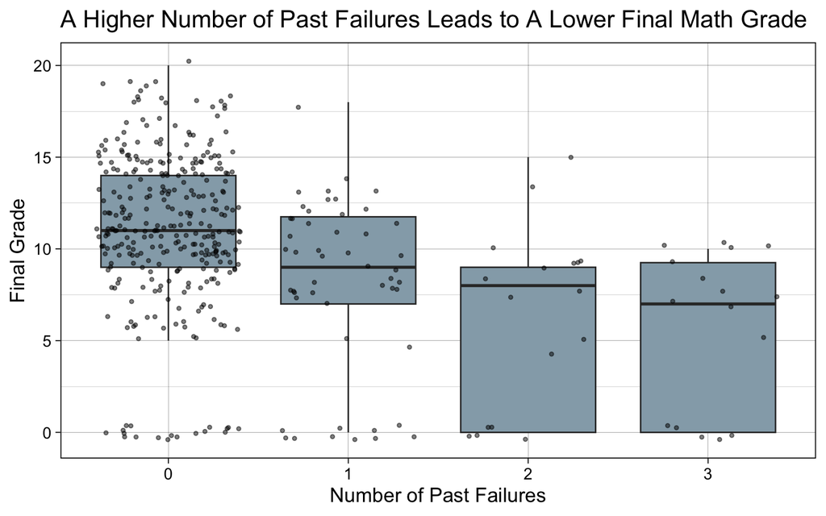

```r
# Box plot, past failures
formatted %>% ggplot(aes(x = as.factor(failures), y = final_grade)) +
  geom_boxplot(outlier.shape = NA, fill = "#95aab7") +
  geom_jitter(color = "black", size = 1, alpha = .5) +
  labs(
    x = "Number of Past Failures",
    y = "Final Grade",
    title = "A Higher Number of Past Failures Leads to A Lower Final Math Grade"
  ) +
  theme_linedraw(base_size = 14)
```

**Students who have failed more often in the past have a lower final grade average.**

### Does weekly study time affect performance consistently across all terms?

```r
# Pivot data to compare grades across periods
long_grade_data <- formatted %>%
  pivot_longer(cols = c(period1_grade, period2_grade, final_grade), names_to = "period", values_to = "grade") %>%
  mutate(period = recode(period,
    period1_grade = "Period 1",
    period2_grade = "Period 2",
    final_grade = "Period 3"
  ))

# Get failure counts per priod by study group
fail_counts <- long_grade_data %>%
  filter(grade == 0) %>%
  group_by(study_time, period) %>%
  summarise(failures = n(), .groups = "drop")

study_boxes <- long_grade_data %>% ggplot(aes(x = factor(study_time), y = grade)) +
  geom_boxplot(fill = "#95aab7") +
  geom_text(
    data = fail_counts,
    aes(
      x = factor(study_time),
      y = -1,
      label = failures
    ),
    inherit.aes = FALSE,
    size = 4,
    color = "red"
  ) +
  facet_wrap(~period) +
  labs(x = "Study Time:   1 = <2hrs,   2 = 2-5hrs,   3 = 5-10hrs,   4 = >10hrs",
       y = "Grade", title = "Grades vs. Weekly Study Time Per Period") +
  theme_linedraw(base_size = 14) +
  theme(axis.title.x = element_text(size = 15), title = element_text(size = 15))
```

[figure not shown]

```r
# Grades over time by study group
study_para <- formatted %>%
  select(period1_grade, period2_grade, final_grade, study_time) %>%
  pivot_longer(cols = c(period1_grade, period2_grade, final_grade), names_to = "period", values_to = "grade") %>%
  mutate(period = factor(period, levels = c("period1_grade", "period2_grade", "final_grade"))) %>%
  group_by(study_time, period) %>%
  summarise(mean_grade = mean(grade), .groups = "drop") %>%
  ggplot(aes(x = period, y = mean_grade, group = study_time,
             color = factor(study_time, levels = sort(unique(study_time), decreasing = TRUE)))) +
  geom_line(size = 1.2) +
  geom_point() +
  labs(x = "Term", y = "Average Grade", color = "Study Time") +
  theme_linedraw(base_size = 14) +
  scale_x_discrete(labels = c(
    period1_grade = "1",
    period2_grade = "2",
    final_grade = "Final"
  )) +
  coord_cartesian(ylim = c(10, 12.75)) +
  scale_y_continuous(breaks = seq(10, 13, by = .5)) +
  theme(axis.title.x = element_text(size = 15), axis.title.y = element_text(size = 15))

# Filter out failing grades
exclude_para <- formatted %>%
  select(period1_grade, period2_grade, final_grade, study_time) %>%
  pivot_longer(cols = c(period1_grade, period2_grade, final_grade), names_to = "period", values_to = "grade") %>%
  filter(grade > 0) %>%
  mutate(period = factor(period, levels = c("period1_grade", "period2_grade", "final_grade"))) %>%
  group_by(study_time, period) %>%
  summarise(mean_grade = mean(grade), .groups = "drop") %>%
  ggplot(aes(
    x = period,
    y = mean_grade,
    group = study_time,
    color = factor(study_time, levels = sort(unique(study_time), decreasing = TRUE))
  )) +
  geom_line(size = 1.2) +
  geom_point() +
  labs(
    x = "Term", y = "Excluding Failures", color = "Study Time",
  ) +
  theme_linedraw(base_size = 14) +
  theme(legend.position = "none") +
  scale_x_discrete(labels = c(
    period1_grade = "1",
    period2_grade = "2",
    final_grade = "Final"
  )) +
  coord_cartesian(ylim = c(10, 12.75)) +
  scale_y_continuous(breaks = seq(10, 13, by = .5)) +
  theme(axis.title.x = element_text(size = 15), axis.title.y = element_text(size = 15))
```

The distribution of student grades across different weekly study time categories for each academic period. The **red text** notates the number of failures for those time periods.

Students in **groups 3 and 4 have moderately higher grades across all periods**, but still have failures in the final period illustrating **studying alone does not prevent poor grades.**

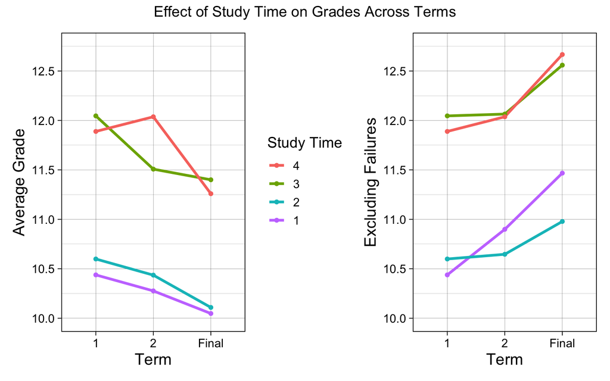

```r
# Paracoords with / without failures side by side
(study_para | exclude_para) +
  plot_layout(widths = c(1, 1)) +
  plot_annotation(title = "Effect of Study Time on Grades Across Terms") &
  theme(
    plot.title = element_text(size = 14, hjust = .5)
  )
```

**Left:** Shows the trending grades of students in each of the 4 study groups throughout the school year. The sharpest decline is group 4 from term 2 to the final- indicating either burnout or lack of information retention due to studying > 10 hours a week. **The consistent decline across all 4 groups from term 1 to final indicated all the averages are being dragged down by failing students.**

## Conclusions

### Limitations

- Bias: Sample is limited to two schools and may not be reflective of wider regions in Portugal or the world.
- Subject: Limited to math students, behaviors math differ across different subjects due to popularity of professions in the region.
- Truthfulness: Data relies on the honesty of students (factors like alcohol use and family relationships).

### Future Steps

- Prediction: Use machine learning to predict performance of a larger population.
- Mental Health: Future surveys to include data on sleep and stress.
- Global Comparison: Compare with results from other regions.

## References

> Shamim, A. (n.d.). Math-Students Performance Data [Data set]. Kaggle. https://www.kaggle.com/datasets/adilshamim8/math-students/data

> Dua, D., & Graff, C. (2017). Student Performance Data Set. UCI Machine Learning Repository. https://archive.ics.uci.edu/dataset/320/student+performance

> P. Cortez and A. Silva. Using Data Mining to Predict Secondary School Student Performance. In A. Brito and J. Teixeira (Eds.), Proceedings of 5th FUture BUsiness TEChnology Conference (FUBUTEC 2008), pp. 5-12, Porto, Portugal, April 2008, EUROSIS, ISBN 978-9077381-39-7.